# Open data survey

“Questions.about.your.usage.of.other.data.sources How.would.you.rate.the.importance.of.each.of.the.following.with.reference.to.determining.the.quality.of.an.openly.accessible.data.set..Use.the.arrows.below.to.go.to.next.statement..there.is.a.total.of.12.statements.to.respond.to.here…..The.data.are.new..e.g..released.within.the.last.year.”

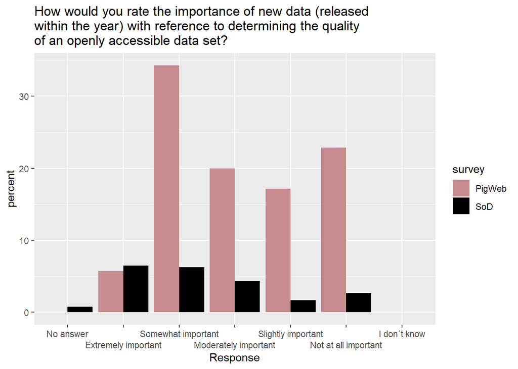

```r
#Creating data sets for column 125 and 128
pigw21Qleonie1 = as.data.frame(dplyr::select(pigw21, 125))
pigw21Pile = cbind(pigw21Pile, pigw21Qleonie1)

sod21Qleonie1 = as.data.frame(dplyr::select(sod21, 128))
sod21Pile = cbind(sod21Pile, sod21Qleonie1)



#Saving the Question text and changing the column name with the responses in the two data frames to Q45
Qleonie1 = "How would you rate the importance of new data (released within the year) with reference to determining the quality of an openly accessible data set? "
colnames(pigw21Qleonie1 ) = c('Qleonie1 ')
colnames(sod21Qleonie1 ) = c('Qleonie1 ')

Qleonie1_levels = c("Extremely important", "Somewhat important", "Moderately important","Slightly important","Not at all important","I don´t know") #The different levels/categories of the questions

Qleonie1_data = format_question_single_choice(sod21Qleonie1$Qleonie1, #Making the answers to Q45 in the two questionnaires comparable, merging them to one data frame
                                         pigw21Qleonie1$Qleonie1,
                                         Qleonie1_levels)

plot_single_choice(Qleonie1_data, #Plotting the responses
                   Qleonie1_levels,
                  Qleonie1,
                   "Response")
```

About.your.research.data…Are.you.aware.of.any.of.the.following.data.or.code.sharing.platforms….EOSC..European.Open.Science.Cloud.

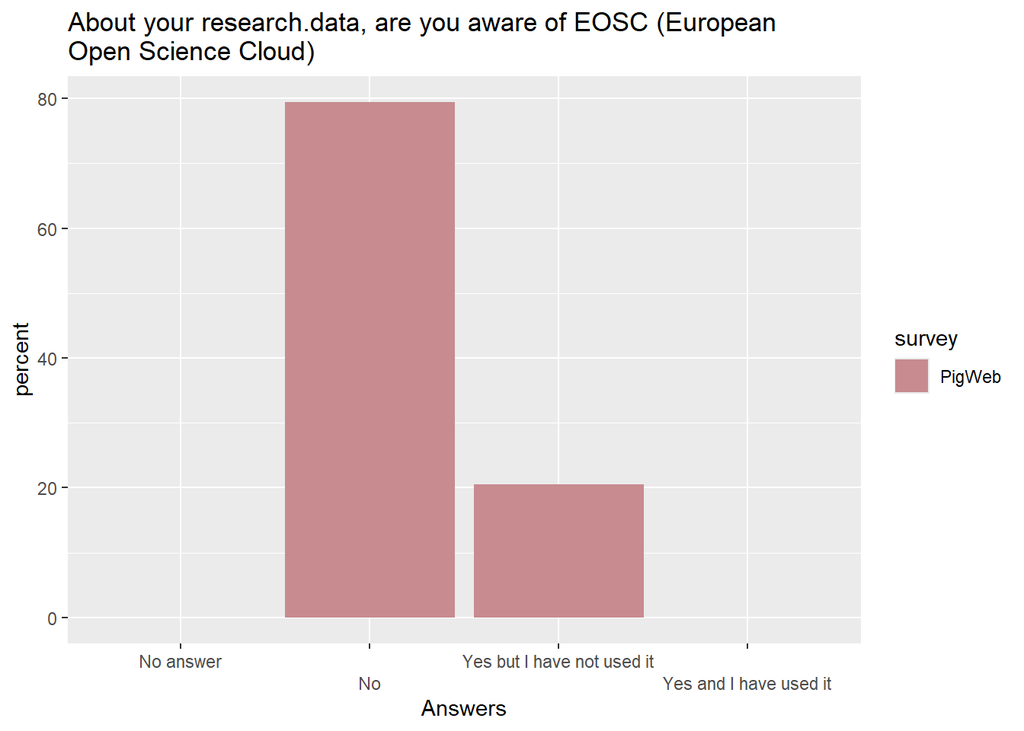

```r
#This is a single choice question without an "other" with responses only in the PigWeb survey.

pigw21Qleonie2 = as.data.frame(dplyr::select(pigw21, 89))


Qleonie2 = 'About your research.data, are you aware of EOSC (European Open Science Cloud)'
colnames(pigw21Qleonie2) = c('Qleonie2')

Qleonie2_levels = c("No", "Yes but I have not used it ", "Yes and I have used it")

#The function is given a 0 instead of the column expected form the SoD survey as there is no question in it.
Qleonie2_data = format_question_single_choice_pigweb(pigw21Qleonie2$Qleonie2,
                                       Qleonie2_levels)

plot_single_choice(Qleonie2_data,
                   Qleonie2_levels,
                   Qleonie2 ,
                   "Answers")
```

# Question 32

**Would you like more guidance on how to comply with the policies of any of the below on making your research data openly available?**

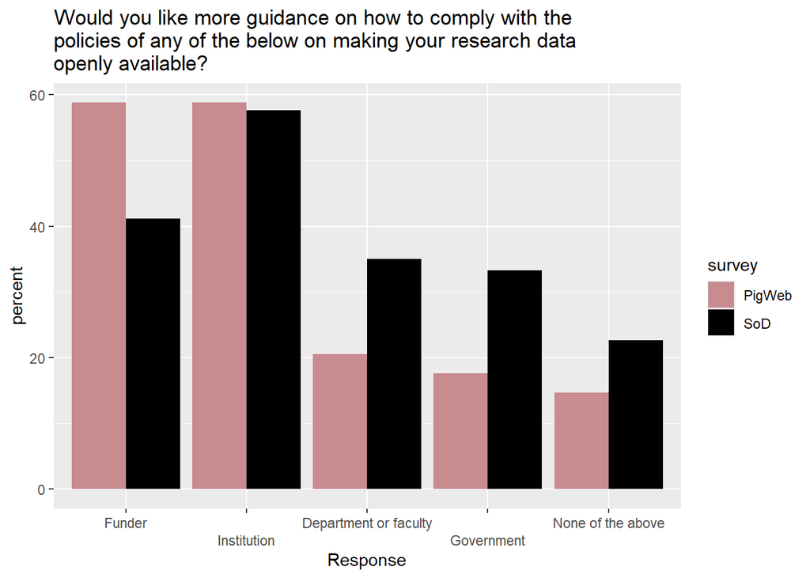

Figure 32

```r
# Answered by Yishu

#This code chunk uses the multiple choice functions.
Q32_levels = c("Funder",
              "Institution",
              "Department or faculty",
              "Government",
              "None of the above")
n_columns = length(Q32_levels)

# Double check that the columns correspond to the right question:
# colnames(sod21)[96]
# colnames(pigw21)[76]

sod21Q32 = as.data.frame(dplyr::select(sod21, (96:sum(96,n_columns,-1))))
sod21Pile = cbind(sod21Pile, sod21Q32)

pigw21Q32 = as.data.frame(dplyr::select(pigw21, (76:sum(76,n_columns-1))))
pigw21Pile = cbind(pigw21Pile, pigw21Q32)

Q32 = 'Would you like more guidance on how to comply with the policies of any of the below on making your research data openly available?'

Q32_data = format_question_multiple_choice(sod21Q32,
                                          pigw21Q32,
                                          Q32_levels)

plot_multiple_choice(Q32_data,
                     Q32_levels,
                     Q32,
                     "Response")
```

# Question 33

**How would you rate the importance of the following with reference to determining the quality of an openly accessible data set? The data are available from a publicly available repository.**

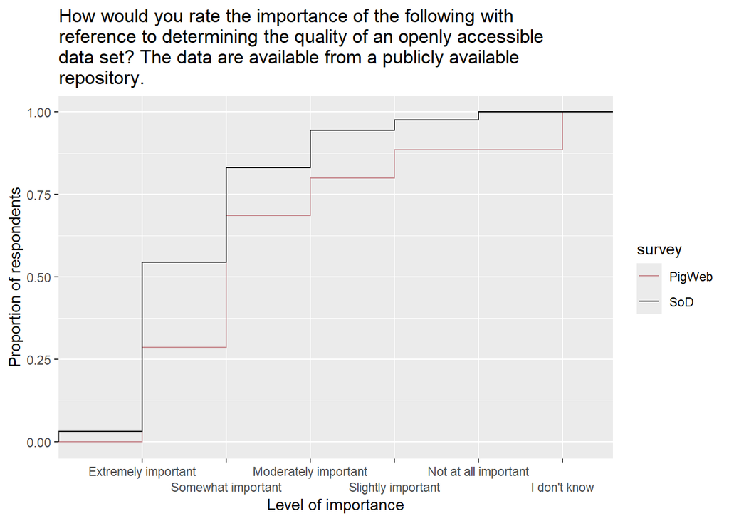

Figure 33

```r
# Answered by Yishu

#This code chunk uses the likert scale functions.

# Double check that the columns correspond to the right question:
# colnames(sod21)[127]
# colnames(pigw21)[124]

#Creating data sets for Q33 (In otherwords: Isolating the responses of Q33 in the two surveys and adding this to a compiled data set, one for each survey)
sod21Q33 = as.data.frame(dplyr::select(sod21,127))
sod21Pile = cbind(sod21Pile, sod21Q33)

pigw21Q33 = as.data.frame(dplyr::select(pigw21, 124))
pigw21Pile = cbind(pigw21Pile, pigw21Q33)


#Setting columnnames and storing the question for Q33
colnames(sod21Q33) = c('Q33')
colnames(pigw21Q33) = c('Q33')
Q33 = 'How would you rate the importance of the following with reference to determining the quality of an openly accessible data set? The data are available from a publicly available repository.'

#Setting the answer options to Q33.
Q33_levels = c("Extremely important", "Somewhat important",
               "Moderately important", "Slightly important",
               "Not at all important", "I don't know")

#The Pigweb scale is correctly formatted for this question (Q33), thus no need to reverse the question.
#pigw21Q33$Q33 = reverseCode(pigw21Q33$Q33)

Q33_data = format_question_likert(sod21Q33$Q33, #Making the answers to Q33 in the two questionnaires comparable, merging them to one data frame
                                  pigw21Q33$Q33,
                                  Q33_levels)

plot_likert(Q33_data,  #Plotting the Level of importance
            Q33_levels,
            Q33,
            "Level of importance")
```

```r
#This section test for if there is statistically significant difference in the respondent groups¨
#with the null hyptohesis that the two populations are the same.

SvPQ33 = ks.test(Q33_data$response[Q33_data$survey == "SoD"],
                 Q33_data$response[Q33_data$survey == "PigWeb"],
                 ifresult = FALSE) #Kolmogorov-Smirnov test for Q33
SvPQ33
```

```
##
##  Asymptotic two-sample Kolmogorov-Smirnov test
##
## data:  Q33_data$response[Q33_data$survey == "SoD"] and Q33_data$response[Q33_data$survey == "PigWeb"]
## D = 0.26, p-value = 0.02
## alternative hypothesis: two-sided
```